# Analysis of diatom host chytrid parasite system for github sharing

– Originally copied at 2026/02/18 from smi_SADIE_beetle_v2.Rmd

– Modified for Miki’s experimental data from the experiment using a simple condition (w/ WC media) only

– Finally copied at 2026/10/24 from smi_diatom_chytrid_v2.Rmd and modified for the publication

## [1] Loading packages and data

```r
R.version
```

```
               _
platform       x86_64-w64-mingw32
arch           x86_64
os             mingw32
crt            ucrt
system         x86_64, mingw32
status
major          4
minor          5.3
year           2026
month          03
day            11
svn rev        89597
language       R
version.string R version 4.5.3 (2026-03-11 ucrt)
nickname       Reassured Reassurer
```

```r
Sys.setlocale("LC_ALL", "English")
```

```
[1] "LC_COLLATE=English_United States.1252;LC_CTYPE=English_United States.1252;LC_MONETARY=English_United States.1252;LC_NUMERIC=C;LC_TIME=English_United States.1252"
```

```r
library(vegan)
library(epiphy)
library(MASS)
library(MuMIn)
library(ggplot2)
library(animation)
library(gganimate)
library(gifski)
library(jpeg)
library(png)
library(car)
library(rgl)
library(nlme) # for using gls()
library(spdep) # Moran's I
source("C:/Users/biomiki/Dropbox/r_local/plot_mod_epiphy.R")
```

```r
##########data loading###########################
chytrid_raw_temp <- read.csv("./exp2026_miki.csv", header = T)
chytrid_raw_data <- chytrid_raw_temp[1:36, ]
print(chytrid_raw_data)
```

|  | count_date | record_ID | sampling_date | day | time | treatment | bottle_ID | inf_00 | inf_01 | inf_02 | inf_03 | inf_04 | inf_05 | inf_06 | inf_07 | inf_08 | inf_09 | inf_10 | inf_11 | inf_12 | inf_13 | inf_14 | inf_15 | inf_16 | inf_17 | inf_18 | inf_19 | inf_20 | inf_21 | … |
| --- | --- | --- | --- | --- | --- | --- | --- | --- | --- | --- | --- | --- | --- | --- | --- | --- | --- | --- | --- | --- | --- | --- | --- | --- | --- | --- | --- | --- | --- | --- |
| 1 | 20260803 | 144 | 2026.05.25 | 0 | 14:05 | control | WC1 | 75 | 3 | 2 | 0 | 0 | 0 | 0 | 0 | 0 | 0 | 0 | 0 | 0 | 0 | 0 | 0 | 0 | 0 | 0 | 0 | 0 | 0 | … |
| 2 | 20260803 | 145 | 2026.05.25 | 0 | 14:05 | control | WC2 | 57 | 0 | 0 | 0 | 0 | 0 | 0 | 0 | 0 | 0 | 0 | 0 | 0 | 0 | 0 | 0 | 0 | 0 | 0 | 0 | 0 | 0 | … |
| 3 | 20260803 | 146 | 2026.05.25 | 0 | 14:05 | control | WC3 | 57 | 4 | 2 | 0 | 0 | 1 | 0 | 0 | 0 | 0 | 0 | 0 | 0 | 0 | 0 | 0 | 0 | 0 | 0 | 0 | 0 | 0 | … |
| 4 | 20260803 | 147 | 2026.05.25 | 0 | 14:05 | control | WC4 | 102 | 1 | 1 | 0 | 0 | 0 | 0 | 0 | 0 | 0 | 0 | 0 | 0 | 0 | 0 | 0 | 0 | 0 | 0 | 0 | 0 | 0 | … |
| 5 | 20260813 | 149 | 2026.05.26 | 1 | 14:25 | control | WC1 | 95 | 3 | 0 | 1 | 0 | 0 | 1 | 0 | 0 | 0 | 0 | 0 | 0 | 0 | 0 | 0 | 0 | 0 | 0 | 0 | 0 | 0 | … |
| 6 | 20260813 | 150 | 2026.05.26 | 1 | 14:25 | control | WC2 | 105 | 0 | 0 | 0 | 0 | 0 | 0 | 0 | 0 | 0 | 0 | 0 | 0 | 0 | 0 | 0 | 0 | 0 | 0 | 0 | 0 | 0 | … |
| 7 | 20260818 | 151 | 2026.05.26 | 1 | 14:25 | control | WC3 | 81 | 30 | 11 | 14 | 8 | 4 | 1 | 2 | 1 | 0 | 0 | 0 | 0 | 0 | 0 | 0 | 0 | 0 | 0 | 0 | 0 | 0 | … |
| 8 | 20260818 | 163 | 2026.05.26 | 1 | 14:25 | control | WC4 | 81 | 10 | 3 | 1 | 0 | 0 | 1 | 0 | 1 | 0 | 0 | 1 | 0 | 0 | 0 | 0 | 0 | 0 | 0 | 0 | 0 | 0 | … |
| 9 | 20260820 | 154 | 2026.05.27 | 2 | 14:30 | control | WC1 | 139 | 34 | 6 | 2 | 0 | 0 | 0 | 0 | 0 | 1 | 0 | 0 | 0 | 0 | 0 | 0 | 0 | 0 | 0 | 0 | 0 | 0 | … |
| 10 | 20260818 | 152 | 2026.05.27 | 2 | 14:30 | control | WC2 | 155 | 17 | 2 | 0 | 0 | 0 | 0 | 0 | 0 | 0 | 0 | 0 | 0 | 0 | 0 | 0 | 0 | 0 | 0 | 0 | 0 | 0 | … |

[output cut: 26 more lines]

## [2] Basic analysis and visualization

### [2.1] Functions to calculate the following metrics

– modified from those in the chytrid analysis

- infestation_ratio, the ratio of the trees with herbivory)
- average adult number (ave_basic), the total number of adults divided by the whole tree number
- average herbivory impact (average_impact), the total number of adults divided by the number of trees with herbivory
- deviation from Poisson distribution
- standardized morisita index

```r
#########mod function copied from  2022/04/06: preparation for kibanA2023##############
chytrid_distr_simple_v3 <- function(data, x_max = 10, LOG = F, title = "Diatom", graph = F, basic = F) {
  #delete long tail with NA
  data <- subset(data, complete.cases(data))

  #infections
  infections <- 0:(length(data) - 1)
  #observed
  observed <- c(data)
  total <- sum(observed)

  #See the estimation of lamda http://www.singularpoint.org/blog/math/stat/cramer-rao-2/
  lambda <- sum(infections * observed) / total

  expected <- total * ((lambda^infections) * exp(-lambda)) / factorial(infections)
  chi.squared <- (observed - expected)^2 / expected

  goodness.of.fit <- cbind(infections, observed, expected)
  colnames(goodness.of.fit) <- c('Infections', 'Observed Counts', 'Expected Counts')

  if(graph == T) {
    xmax <- x_max
    if(LOG == T) {
      plot(infections, log10(observed), xlim = c(0,xmax), ylim = c(-0,3), cex = 3, pch = 16, cex.axis = 2, main = title)
      lines(infections, log10(expected), col = 1, cex = 2, lwd = 3, lty = 2)
    }
    else {
      plot(infections, observed, xlim = c(0,xmax),cex=3, ylim=c(0,max(observed+10)), main=title)
      lines(infections, expected, col = 1, cex = 2, lwd=3,lty=2)
    }
  }

  chi.squared.statistic = sum(chi.squared)

  #P Value for the Poisson distribution
  P_chisq_Poission <- pchisq(chi.squared.statistic, length(observed)-2, lower.tail = F)

  #For preparation for Morisita index calculation
  data3 <- c(0, 0, 0)  #dummy data

  j <- 1
  k <- 0
  m <- 1
  while(m <= total & j <= length(observed)) {
    if(observed[j] == 0) j <- j + 1
    else if (m > k && m <= k + observed[j]) {
      data3[m] <- j - 1
      m <- m + 1
    }
    else if (m == k + observed[j] + 1) {
      k <- k + observed[j]
      j <- j + 1
    }
  }

  ##Morisita index from library(vegan)
  data4 <- t(t(data3))
  morisita <- dispindmorisita(data4, unique.rm = FALSE, crit = 0.05)
  #imst is the standardized Morisita index: (-0.5:0.5) are confidence interval for random distribution

  #infection rate
  infection_rate <- 1.0 - observed[1] / total
  if(basic == T) {
    cat("The counted number of cells is:", total, "\n")
    cat("The counted number of infections is:", sum(infections*observed), "\n")
    cat("The infection rate is:", infection_rate, "\n")
    cat("The averaged number of infection per cell is:", lambda, "\n")
    cat("The probability with which Poisson distribution generates more extreme deviation:", P_chisq_Poission, "\n")
    cat("The standardized morisita index value is :", morisita$imst, "\n")

  }
    #cat("The data looks like\n")
  return(morisita$imst)
}
```

- slightly modified version v4, instead of standardized morisita index, using morisita itself

```r
#########mod function copied from  2022/04/06: preparation for kibanA2023##############
chytrid_distr_simple_v4 <- function(data, x_max = 10, LOG = F, title = "Diatom", graph = F, basic = F) {
  #delete long tail with NA
  data <- subset(data, complete.cases(data))

  #infections
  infections <- 0:(length(data) - 1)
  #observed
  observed <- c(data)
  total <- sum(observed)

  #See the estimation of lamda http://www.singularpoint.org/blog/math/stat/cramer-rao-2/
  lambda <- sum(infections * observed) / total

  expected <- total * ((lambda^infections) * exp(-lambda)) / factorial(infections)
  chi.squared <- (observed - expected)^2 / expected

  goodness.of.fit <- cbind(infections, observed, expected)
  colnames(goodness.of.fit) <- c('Infections', 'Observed Counts', 'Expected Counts')

  if(graph == T) {
    xmax <- x_max
    if(LOG == T) {
      df_plot <- data.frame(
      infections = infections,
      observed   = observed,
      expected   = expected
      )

      p <- ggplot(df_plot, aes(x = infections)) +
        geom_point(
        aes(y = observed),
        shape = 16,
        size = 5.0
      ) +
      geom_line(
        aes(y = expected),
        linetype = "dashed",
        linewidth = 1.0
      ) +
      scale_x_continuous(
        limits = c(0, x_max),
        breaks = seq(0, x_max, 2)
      ) +
      scale_y_continuous(
        trans = "log1p",
        breaks = c(0, 1, 2, 5, 10, 20, 50, 100, 150, 200, 500)
      ) +
      labs(
        x = "Infection Intensity (# infections)",
        y = "Cell Abundance (Frequency)"
      ) +
      theme_bw() +
      theme(
        panel.grid = element_blank(),
        aspect.ratio = 1.0
      )
      print(p)
    }

    else {
      plot(infections, observed, xlim = c(0,xmax), cex = 3, ylim = c(0, max(observed + 10)), main=title)
      lines(infections, expected, col = 1, cex = 2, lwd = 3,lty = 2)
    }
  }

  chi.squared.statistic = sum(chi.squared)

  #P Value for the Poisson distribution
  P_chisq_Poission <- pchisq(chi.squared.statistic, length(observed)-2, lower.tail = F)

  #For preparation for Morisita index calculation
  data3 <- c(0, 0, 0)  #dummy data

  j <- 1
  k <- 0
  m <- 1
  while(m <= total & j <= length(observed)) {
    if(observed[j] == 0) j <- j + 1
    else if (m > k && m <= k + observed[j]) {
      data3[m] <- j - 1
      m <- m + 1
    }
    else if (m == k + observed[j] + 1) {
      k <- k + observed[j]
      j <- j + 1
    }
  }

  ##Morisita index from library(vegan)
  data4 <- t(t(data3))
  morisita <- dispindmorisita(data4, unique.rm = FALSE, crit = 0.05)
  #imst is the standardized Morisita index: (-0.5:0.5) are confidence interval for random distribution

  #infection rate
  infection_rate <- 1.0 - observed[1] / total
  if(basic == T) {
    cat("The counted number of cells is:", total, "\n")
    cat("The counted number of infections is:", sum(infections*observed), "\n")
    cat("The infection rate is:", infection_rate, "\n")
    cat("The averaged number of infection per cell is:", lambda, "\n")
    cat("The probability with which Poisson distribution generates more extreme deviation:", P_chisq_Poission, "\n")
    cat("The morisita index value is :", morisita$imor, "\n")
    cat("The standardized morisita index value is :", morisita$imst, "\n")

  }
    #cat("The data looks like\n")
  return(morisita$imor)
}
```

– specific growth rate

```r
specific_growth <- function(value_vec, time_vec, tau = 1) {
  vec_length <- length(value_vec)
  growth <- numeric(vec_length)

  for(j in 1:vec_length) {
    if(j + tau - 1 < 1 || j + tau > vec_length) growth[j] <- NA
    else {
      growth[j] <- log(value_vec[j + tau] / value_vec[j + tau - 1]) / (time_vec[j + tau] - time_vec[j + tau - 1])
      if(value_vec[j + tau] == 0 & value_vec[j + tau - 1] == 0) growth[j] <- 0 #exception
    }
    if(is.infinite(growth[j])) growth[j] <- NA
  }
  # Noting that the value is not calculated at the final time point
  return(growth)
}
```

#### Trial

```r
infection_range <- 0:25
print(chytrid_raw_data[1, 8 + infection_range])
```

|  | inf_00 | inf_01 | inf_02 | inf_03 | inf_04 | inf_05 | inf_06 | inf_07 | inf_08 | inf_09 | inf_10 | inf_11 | inf_12 | inf_13 | inf_14 | inf_15 | inf_16 | inf_17 | inf_18 | inf_19 | inf_20 | inf_21 | inf_22 | inf_23 | inf_24 | inf_25 |
| --- | --- | --- | --- | --- | --- | --- | --- | --- | --- | --- | --- | --- | --- | --- | --- | --- | --- | --- | --- | --- | --- | --- | --- | --- | --- | --- |
| 1 | 75 | 3 | 2 | 0 | 0 | 0 | 0 | 0 | 0 | 0 | 0 | 0 | 0 | 0 | 0 | 0 | 0 | 0 | 0 | 0 | 0 | 0 | 0 | 0 | 0 | 0 |

```
The counted number of cells is: 80
The counted number of infections is: 7
The infection rate is: 0.0625
The averaged number of infection per cell is: 0.0875
The probability with which Poisson distribution generates more extreme deviation: 0.9750034
The morisita index value is : 7.619048
The standardized morisita index value is : 0.5147941
[1] 7.619048
```

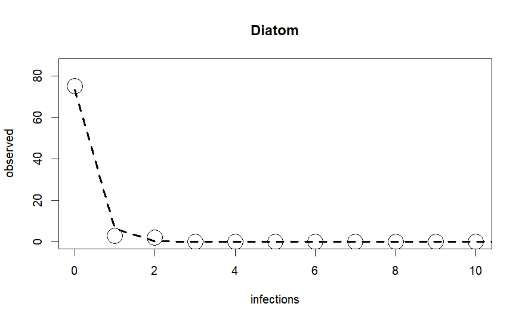

```r
chytrid_distr_simple_v4(unlist(chytrid_raw_data[1, 8 + infection_range]), graph = T, basic = T)
```

```
The counted number of cells is: 597
The counted number of infections is: 1509
The infection rate is: 0.8509213
The averaged number of infection per cell is: 2.527638
The probability with which Poisson distribution generates more extreme deviation: 0
The morisita index value is : 1.43139
The standardized morisita index value is : 0.5003232
[1] 1.43139
```

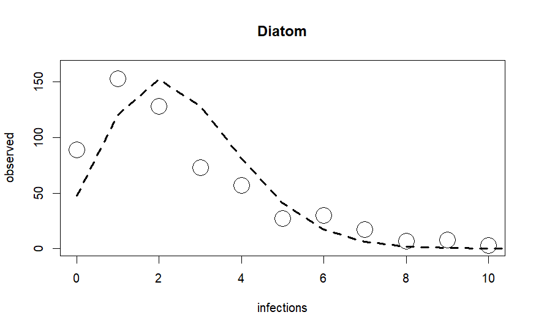

```r
chytrid_distr_simple_v4(unlist(chytrid_raw_data[29, 8 + infection_range]), graph = T, basic = T)
```

```r
chytrid_distr_simple_v4(unlist(chytrid_raw_data[1, 8 + infection_range]), graph = F, basic = F)
```

```
[1] 7.619048
```

### [2.2] Calculating infection rate and number of infections

```r
sporangia <- 0
for(i in infection_range) sporangia <- sporangia + i * chytrid_raw_data[, 8 + i]
chytrid_summary_temp <- data.frame(
  day = chytrid_raw_data$day,
  treatment = chytrid_raw_data$treatment,
  bottle_ID = chytrid_raw_data$bottle_ID,
  diatom = apply(chytrid_raw_data[, 8 + infection_range], 1, sum),
  infection_ratio = 1 - chytrid_raw_data[, 8] / apply(chytrid_raw_data[, 8 + infection_range], 1, sum),
  chytrid_sporangia = sporangia
)
print(chytrid_summary_temp)
```

|  | day | treatment | bottle_ID | diatom | infection_ratio | chytrid_sporangia |
| --- | --- | --- | --- | --- | --- | --- |
| 1 | 0 | control | WC1 | 80 | 0.06250000 | 7 |
| 2 | 0 | control | WC2 | 57 | 0.00000000 | 0 |
| 3 | 0 | control | WC3 | 64 | 0.10937500 | 13 |
| 4 | 0 | control | WC4 | 104 | 0.01923077 | 3 |
| 5 | 1 | control | WC1 | 100 | 0.05000000 | 12 |
| 6 | 1 | control | WC2 | 105 | 0.00000000 | 0 |
| 7 | 1 | control | WC3 | 152 | 0.46710526 | 174 |
| 8 | 1 | control | WC4 | 98 | 0.17346939 | 44 |
| 9 | 2 | control | WC1 | 182 | 0.23626374 | 61 |
| 10 | 2 | control | WC2 | 174 | 0.10919540 | 21 |

[output cut: 26 more lines]

### [2.3] Calculating morisita index and rates

```r
#morisita
std_mi <- list()
raw_mi <- list()
for(i in 1:length(chytrid_raw_data[, 1])) {
  std_mi[[i]] <- chytrid_distr_simple_v3(unlist(chytrid_raw_data[i, 8 + infection_range]))
  raw_mi[[i]] <- chytrid_distr_simple_v4(unlist(chytrid_raw_data[i, 8 + infection_range]))
}
chytrid_summary_temp$std_mi <- unlist(std_mi)
chytrid_summary_temp$raw_mi <- unlist(raw_mi)

print(chytrid_summary_temp)
```

|  | day | treatment | bottle_ID | diatom | infection_ratio | chytrid_sporangia | std_mi | raw_mi |
| --- | --- | --- | --- | --- | --- | --- | --- | --- |
| 1 | 0 | control | WC1 | 80 | 0.06250000 | 7 | 0.51479411 | 7.619048 |
| 2 | 0 | control | WC2 | 57 | 0.00000000 | 0 | NaN | NaN |
| 3 | 0 | control | WC3 | 64 | 0.10937500 | 13 | 0.55621933 | 9.846154 |
| 4 | 0 | control | WC4 | 104 | 0.01923077 | 3 | 0.60611727 | 34.666667 |
| 5 | 1 | control | WC1 | 100 | 0.05000000 | 12 | 0.62249122 | 27.272727 |
| 6 | 1 | control | WC2 | 105 | 0.00000000 | 0 | NaN | NaN |
| 7 | 1 | control | WC3 | 152 | 0.46710526 | 174 | 0.50356378 | 2.282373 |
| 8 | 1 | control | WC4 | 98 | 0.17346939 | 44 | 0.54721688 | 10.773784 |
| 9 | 2 | control | WC1 | 182 | 0.23626374 | 61 | 0.50865360 | 4.773770 |
| 10 | 2 | control | WC2 | 174 | 0.10919540 | 21 | 0.17151834 | 1.657143 |

[output cut: 26 more lines]

#### Data stratification for calculating growth rate

– Data stratification for calculating growth rate

```r
# splitting the data set into the list based on the monitoring date ID, treatment, and bottle_ID
split_diatom <- split(chytrid_summary_temp$diatom, list(chytrid_summary_temp$bottle_ID, chytrid_summary_temp$treatment))

split_sporangia <- split(chytrid_summary_temp$chytrid_sporangia, list(chytrid_summary_temp$bottle_ID, chytrid_summary_temp$treatment))

split_infection_ratio <- split(chytrid_summary_temp$infection_ratio, list(chytrid_summary_temp$bottle_ID, chytrid_summary_temp$treatment))

split_std_mi <- split(chytrid_summary_temp$std_mi, list(chytrid_summary_temp$bottle_ID, chytrid_summary_temp$treatment))

split_raw_mi <- split(chytrid_summary_temp$raw_mi, list(chytrid_summary_temp$bottle_ID, chytrid_summary_temp$treatment))

split_dayN2 <- split(chytrid_summary_temp$day, list(chytrid_summary_temp$bottle_ID, chytrid_summary_temp$treatment))

split_treatment <- split(chytrid_summary_temp$treatment, list(chytrid_summary_temp$bottle_ID, chytrid_summary_temp$treatment))
split_bottle_ID <- split(chytrid_summary_temp$bottle_ID, list(chytrid_summary_temp$bottle_ID, chytrid_summary_temp$treatment))
```

### [2.4] Calculating the growth rate

#### With tau = 1

```r
diatom_growth_list_1 <- mapply(specific_growth, split_diatom, split_dayN2, MoreArgs = list(tau = 1), SIMPLIFY = FALSE)
popl_growth_list_1 <- mapply(specific_growth, split_sporangia, split_dayN2, MoreArgs = list(tau = 1), SIMPLIFY = FALSE)
prev_growth_list_1 <- mapply(specific_growth, split_infection_ratio, split_dayN2, MoreArgs = list(tau = 1), SIMPLIFY = FALSE)
```

- Summarizing them into the dataframe

```r
chytrid_summary <- data.frame(
  dayN = unlist(split_dayN2),
  treatment = unlist(split_treatment),
  bottle_ID = unlist(split_bottle_ID),
  diatom = unlist(split_diatom),
  sporangia = unlist(split_sporangia),
  infection_ratio = unlist(split_infection_ratio),
  diatom_growth_1 = unlist(diatom_growth_list_1),
  popl_growth_1 = unlist(popl_growth_list_1),
  prev_growth_1 = unlist(prev_growth_list_1),
  std_mi = unlist(split_std_mi),
  raw_mi = unlist(split_raw_mi)
)
chytrid_summary2 <- data.frame(
  treatment_bottle = paste(chytrid_summary$treatment, chytrid_summary$bottle_ID, sep = "_"),
  chytrid_summary
)
print(chytrid_summary2)
```

|  | treatment_bottle | dayN | treatment | bottle_ID | diatom | sporangia | infection_ratio | diatom_growth_1 | popl_growth_1 | prev_growth_1 | std_mi | raw_mi |
| --- | --- | --- | --- | --- | --- | --- | --- | --- | --- | --- | --- | --- |
| WC1.control1 | control_WC1 | 0 | control | WC1 | 80 | 7 | 0.06250000 | 0.22314355 | 0.53899650 | -0.22314355 | 0.51479411 | 7.619048 |
| WC1.control2 | control_WC1 | 1 | control | WC1 | 100 | 12 | 0.05000000 | 0.59883650 | 1.62596721 | 1.55292570 | 0.62249122 | 27.272727 |
| WC1.control3 | control_WC1 | 2 | control | WC1 | 182 | 61 | 0.23626374 | 0.43434798 | 0.30796674 | -0.36690670 | 0.50865360 | 4.773770 |
| WC1.control4 | control_WC1 | 3 | control | WC1 | 281 | 83 | 0.16370107 | 0.63640735 | 1.23364857 | 0.67661481 | 0.51208188 | 8.339994 |
| WC1.control5 | control_WC1 | 4 | control | WC1 | 531 | 285 | 0.32203390 | 0.08826608 | 0.67723173 | 0.51307355 | 0.50136415 | 2.676649 |
| WC1.control6 | control_WC1 | 5 | control | WC1 | 580 | 561 | 0.53793103 | 0.12785544 | 0.34746406 | 0.14084089 | 0.50074632 | 1.986504 |
| WC1.control7 | control_WC1 | 7 | control | WC1 | 749 | 1124 | 0.71295060 | -0.22682187 | 0.29455343 | 0.17690748 | 0.50049989 | 1.816941 |
| WC1.control8 | control_WC1 | 8 | control | WC1 | 597 | 1509 | 0.85092127 | -0.28148575 | -0.36445071 | -0.03269557 | 0.50032324 | 1.431390 |
| WC1.control9 | control_WC1 | 10 | control | WC1 | 340 | 728 | 0.79705882 | NA | NA | NA | 0.50031662 | 1.287392 |
| WC2.control1 | control_WC2 | 0 | control | WC2 | 57 | 0 | 0.00000000 | 0.61090908 | 0.00000000 | 0.00000000 | NaN | NaN |

[output cut: 26 more lines]

### [2.5] Basic visualization

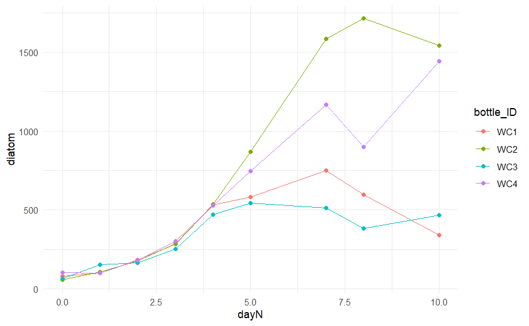

```r
ggplot(chytrid_summary2, aes(x = dayN, y = diatom, group = treatment_bottle, color = bottle_ID)) +
  geom_line() +
  geom_point() +
  #scale_y_log10() +
  theme_minimal()
```

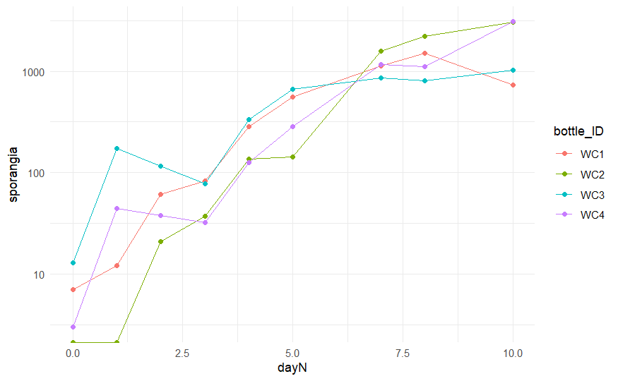

```r
ggplot(chytrid_summary2, aes(x = dayN, y = sporangia, group = treatment_bottle, color = bottle_ID)) +
  geom_line() +
  geom_point() +
  scale_y_log10() +
  theme_minimal()
```

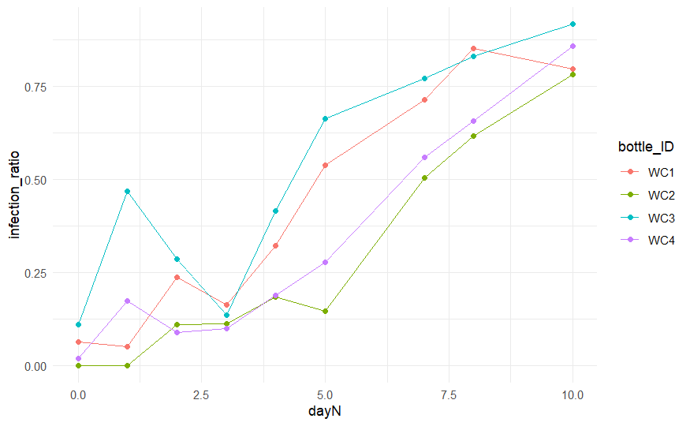

```r
ggplot(chytrid_summary2, aes(x = dayN, y = infection_ratio, group = treatment_bottle, color = bottle_ID)) +
  geom_line() +
  geom_point() +
  #scale_y_log10() +
  theme_minimal()
```

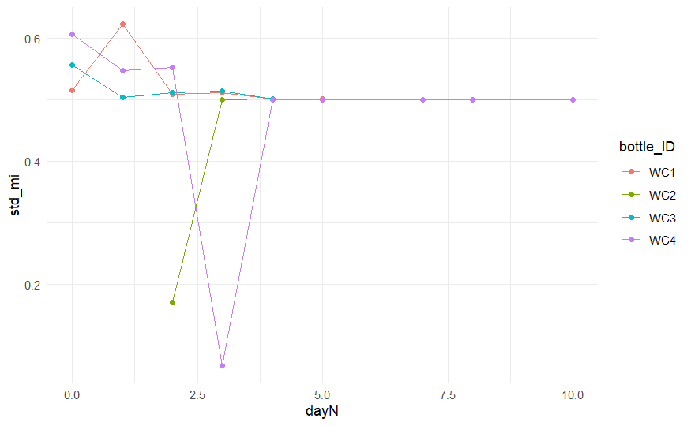

```r
ggplot(chytrid_summary2, aes(x = dayN, y = std_mi, group = treatment_bottle, color = bottle_ID)) +
  geom_line() +
  geom_point() +
  #scale_y_log10() +
  theme_minimal()
```

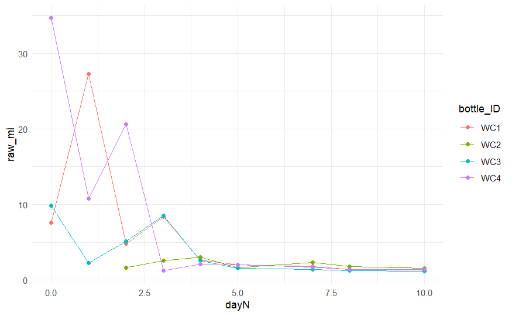

```r
ggplot(chytrid_summary2, aes(x = dayN, y = raw_mi, group = treatment_bottle, color = bottle_ID)) +
  geom_line() +
  geom_point() +
  #scale_y_log10() +
  theme_minimal()
```

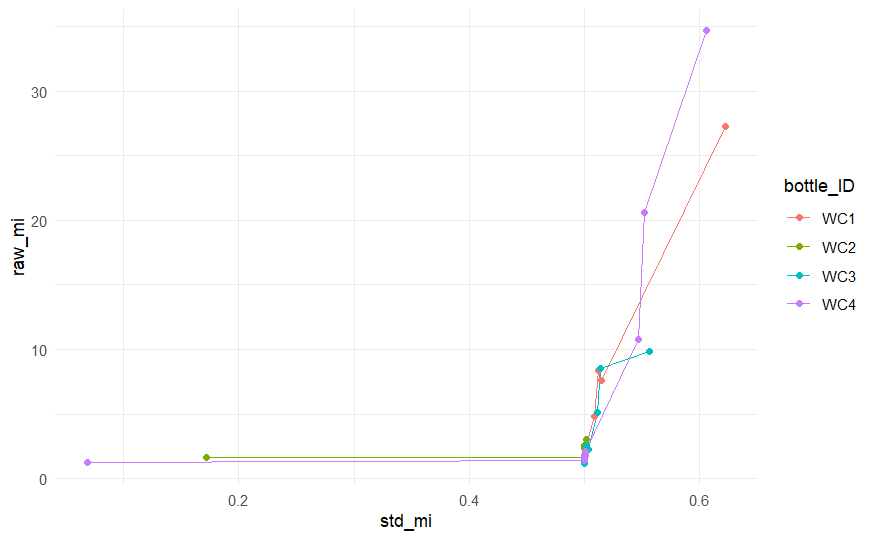

```r
ggplot(chytrid_summary2, aes(x = std_mi, y = raw_mi, group = treatment_bottle, color = bottle_ID)) +
  geom_line() +
  geom_point() +
  #scale_y_log10() +
  theme_minimal()
```

### [2.6] Rate-related visualization

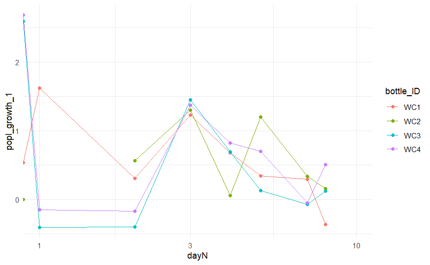

```r
ggplot(chytrid_summary2, aes(x = dayN, y = popl_growth_1, group = treatment_bottle, color = bottle_ID)) +
  geom_line() +
  geom_point() +
  scale_x_log10() +
  theme_minimal()
```

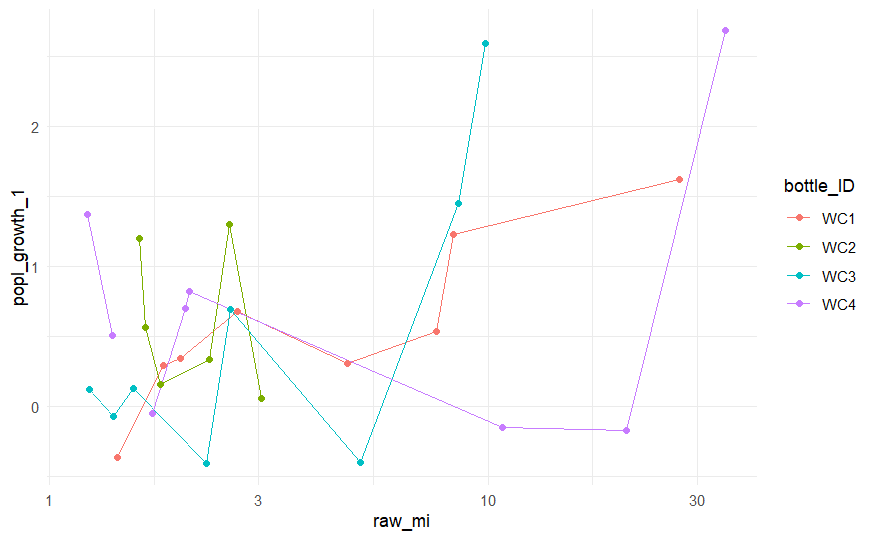

```r
ggplot(chytrid_summary2, aes(x = raw_mi, y = popl_growth_1, group = treatment_bottle, color = bottle_ID)) +
  geom_line() +
  geom_point() +
  scale_x_log10() +
  theme_minimal()
```

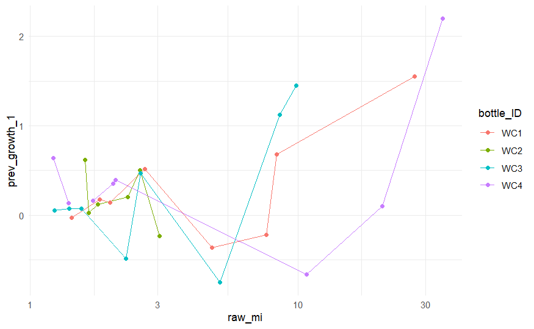

```r
ggplot(chytrid_summary2, aes(x = raw_mi, y = prev_growth_1, group = treatment_bottle, color = bottle_ID)) +
  geom_line() +
  geom_point() +
  scale_x_log10() +
  theme_minimal()
```

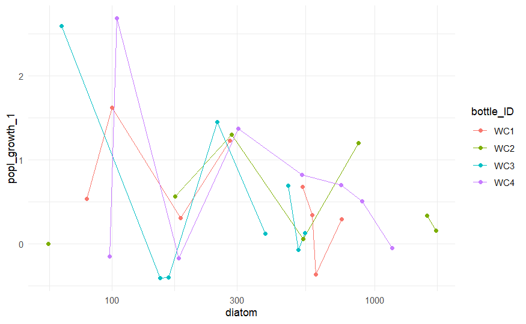

```r
ggplot(chytrid_summary2, aes(x = diatom, y = popl_growth_1, group = treatment_bottle, color = bottle_ID)) +
  geom_line() +
  geom_point() +
  scale_x_log10() +
  theme_minimal()
```

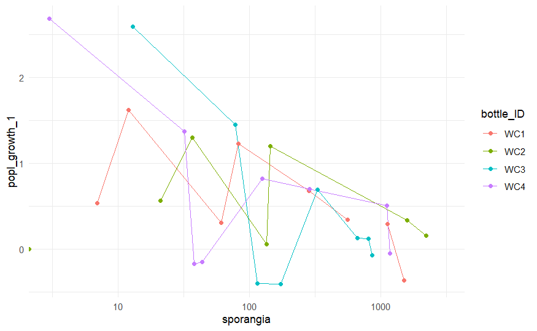

```r
ggplot(chytrid_summary2, aes(x = sporangia, y = popl_growth_1, group = treatment_bottle, color = bottle_ID)) +
  geom_line() +
  geom_point() +
  scale_x_log10() +
  theme_minimal()
```

## [3] Time series analysis

### [3.1] Trial

```r
chytrid_summary_temp <- subset(chytrid_summary2, !is.na(popl_growth_1) & !is.na(std_mi))
#chytrid_summary_temp_control <- subset(chytrid_summary_temp, treatment == "control")
```

```r
#with unequal interval
m2_cont <- gls(popl_growth_1 ~ diatom + sporangia + raw_mi,
          data = chytrid_summary_temp,
          correlation = corCAR1(form = ~ dayN | treatment_bottle),
          method = "REML")
summary(m2_cont)
```

```
Generalized least squares fit by REML
  Model: popl_growth_1 ~ diatom + sporangia + raw_mi
  Data: chytrid_summary_temp
```

|  | AIC | BIC | logLik |
| --- | --- | --- | --- |
|  | 105.4159 | 112.9645 | -46.70796 |

```
Correlation Structure: Continuous AR(1)
 Formula: ~dayN | treatment_bottle
 Parameter estimate(s):
         Phi
1.352947e-09

Coefficients:
```

|  | Value | Std.Error | t-value | p-value |
| --- | --- | --- | --- | --- |
| (Intercept) | 0.27961440 | 0.25819029 | 1.082978 | 0.2888 |
| diatom | 0.00088901 | 0.00056577 | 1.571344 | 0.1282 |
| sporangia | -0.00085206 | 0.00039447 | -2.160013 | 0.0402 |
| raw_mi | 0.04666334 | 0.01700676 | 2.743812 | 0.0109 |

```
 Correlation:
          (Intr) diatom sporng
diatom    -0.602
sporangia  0.179 -0.818
raw_mi    -0.654  0.230  0.026

Standardized residuals:
        Min          Q1         Med          Q3         Max
-2.32499782 -0.23400033  0.06613422  0.32589110  2.73033424

Residual standard error: 0.6626357
Degrees of freedom: 30 total; 26 residual
```

```r
summary(m2_cont)$tTable
```

```
                    Value    Std.Error   t-value    p-value
(Intercept)  0.2796144044 0.2581902935  1.082978 0.28875989
diatom       0.0008890147 0.0005657671  1.571344 0.12819421
sporangia   -0.0008520608 0.0003944703 -2.160013 0.04017132
raw_mi       0.0466633434 0.0170067560  2.743812 0.01085702
```

```r
#with unequal interval
m2_cont <- gls(popl_growth_1 ~ diatom + sporangia + raw_mi,
          data = chytrid_summary_temp,
          correlation = corCAR1(form = ~ dayN | treatment_bottle),
          method = "REML")
summary(m2_cont)
```

```
Generalized least squares fit by REML
  Model: popl_growth_1 ~ diatom + sporangia + raw_mi
  Data: chytrid_summary_temp
```

|  | AIC | BIC | logLik |
| --- | --- | --- | --- |
|  | 105.4159 | 112.9645 | -46.70796 |

```
Correlation Structure: Continuous AR(1)
 Formula: ~dayN | treatment_bottle
 Parameter estimate(s):
         Phi
1.352947e-09

Coefficients:
```

|  | Value | Std.Error | t-value | p-value |
| --- | --- | --- | --- | --- |
| (Intercept) | 0.27961440 | 0.25819029 | 1.082978 | 0.2888 |
| diatom | 0.00088901 | 0.00056577 | 1.571344 | 0.1282 |
| sporangia | -0.00085206 | 0.00039447 | -2.160013 | 0.0402 |
| raw_mi | 0.04666334 | 0.01700676 | 2.743812 | 0.0109 |

```
 Correlation:
          (Intr) diatom sporng
diatom    -0.602
sporangia  0.179 -0.818
raw_mi    -0.654  0.230  0.026

Standardized residuals:
        Min          Q1         Med          Q3         Max
-2.32499782 -0.23400033  0.06613422  0.32589110  2.73033424

Residual standard error: 0.6626357
Degrees of freedom: 30 total; 26 residual
```

```r
summary(m2_cont)$tTable
```

```
                    Value    Std.Error   t-value    p-value
(Intercept)  0.2796144044 0.2581902935  1.082978 0.28875989
diatom       0.0008890147 0.0005657671  1.571344 0.12819421
sporangia   -0.0008520608 0.0003944703 -2.160013 0.04017132
raw_mi       0.0466633434 0.0170067560  2.743812 0.01085702
```

```r
m22_cont <- gls(popl_growth_1 ~ diatom + sporangia,
          data = chytrid_summary_temp,
          correlation = corCAR1(form = ~ dayN | treatment_bottle),
          method = "REML")
summary(m22_cont)
```

```
Generalized least squares fit by REML
  Model: popl_growth_1 ~ diatom + sporangia
  Data: chytrid_summary_temp
```

|  | AIC | BIC | logLik |
| --- | --- | --- | --- |
|  | 103.9526 | 110.4318 | -46.9763 |

```
Correlation Structure: Continuous AR(1)
 Formula: ~dayN | treatment_bottle
 Parameter estimate(s):
         Phi
6.813262e-10

Coefficients:
```

|  | Value | Std.Error | t-value | p-value |
| --- | --- | --- | --- | --- |
| (Intercept) | 0.7431851 | 0.21756470 | 3.415927 | 0.0020 |
| diatom | 0.0005314 | 0.00061351 | 0.866090 | 0.3941 |
| sporangia | -0.0008807 | 0.00043943 | -2.004214 | 0.0552 |

```
 Correlation:
          (Intr) diatom
diatom    -0.614
sporangia  0.260 -0.847

Standardized residuals:
       Min         Q1        Med         Q3        Max
-1.5235975 -0.4333085 -0.1306619  0.5136519  2.5592328

Residual standard error: 0.7384142
Degrees of freedom: 30 total; 27 residual
```

```r
summary(m22_cont)$tTable
```

```
                    Value    Std.Error    t-value     p-value
(Intercept)  0.7431851039 0.2175646964  3.4159269 0.002026266
diatom       0.0005313510 0.0006135056  0.8660899 0.394072145
sporangia   -0.0008807067 0.0004394276 -2.0042136 0.055172753
```

- visualization

```r
pred_m_cont <- data.frame(
  obs = chytrid_summary_temp$popl_growth_1,
  pred_dia_spor_mi = predict(m2_cont, newdata = chytrid_summary_temp),
  pred_dia_spor = predict(m22_cont, newdata = chytrid_summary_temp)
)

pred_long_cont <- rbind(
  data.frame(model = "dia_spor_mi", pred = pred_m_cont$pred_dia_spor_mi, obs = pred_m_cont$obs),
  data.frame(model = "dia_spor", pred = pred_m_cont$pred_dia_spor, obs = pred_m_cont$obs)
)
```

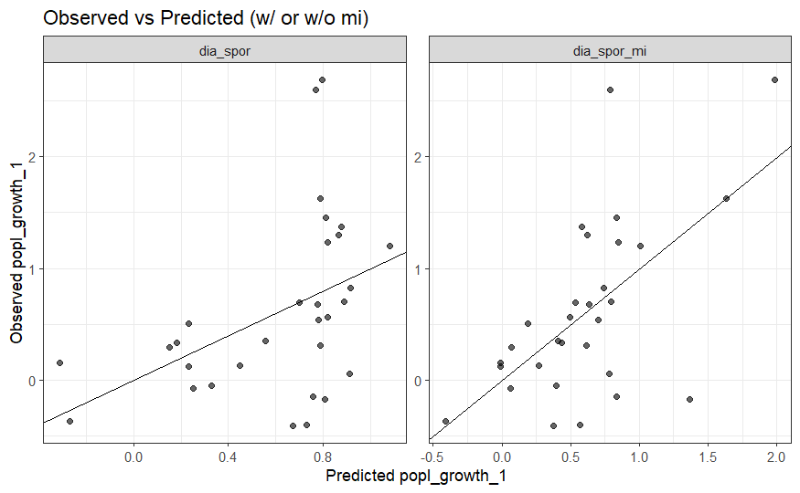

```r
ggplot(pred_long_cont, aes(x = pred, y = obs)) +
  geom_point(alpha = 0.6) +
  geom_abline(slope = 1, intercept = 0) +
  facet_wrap(~ model, scales = "free") +
  labs(y = "Observed popl_growth_1",
       x = "Predicted popl_growth_1",
       title = "Observed vs Predicted (w/ or w/o mi)") +
  theme_bw()
```

- prepare several lists

```r
candidate_formulas <- list()
results_LORO <- list()
score_table <- list()
final_fit <- list()
best_model_name <- list()
best_formula <- list()
```

### [3.2] Population growth rate 1 by AR1 model

```r
## =========================================================
## 1) Data prearrangement
## =========================================================
chytrid_summary_ar <- subset(chytrid_summary2, !is.na(popl_growth_1) & !is.na(std_mi))
chytrid_summary_ar$treatment_bottle <- as.factor(chytrid_summary_ar$treatment_bottle)
chytrid_summary_ar$treatment <- as.factor(chytrid_summary_ar$treatment)
print(chytrid_summary_ar)
```

|  | treatment_bottle | dayN | treatment | bottle_ID | diatom | sporangia | infection_ratio | diatom_growth_1 | popl_growth_1 | prev_growth_1 | std_mi | raw_mi |
| --- | --- | --- | --- | --- | --- | --- | --- | --- | --- | --- | --- | --- |
| WC1.control1 | control_WC1 | 0 | control | WC1 | 80 | 7 | 0.06250000 | 0.22314355 | 0.53899650 | -0.22314355 | 0.51479411 | 7.619048 |
| WC1.control2 | control_WC1 | 1 | control | WC1 | 100 | 12 | 0.05000000 | 0.59883650 | 1.62596721 | 1.55292570 | 0.62249122 | 27.272727 |
| WC1.control3 | control_WC1 | 2 | control | WC1 | 182 | 61 | 0.23626374 | 0.43434798 | 0.30796674 | -0.36690670 | 0.50865360 | 4.773770 |
| WC1.control4 | control_WC1 | 3 | control | WC1 | 281 | 83 | 0.16370107 | 0.63640735 | 1.23364857 | 0.67661481 | 0.51208188 | 8.339994 |
| WC1.control5 | control_WC1 | 4 | control | WC1 | 531 | 285 | 0.32203390 | 0.08826608 | 0.67723173 | 0.51307355 | 0.50136415 | 2.676649 |
| WC1.control6 | control_WC1 | 5 | control | WC1 | 580 | 561 | 0.53793103 | 0.12785544 | 0.34746406 | 0.14084089 | 0.50074632 | 1.986504 |
| WC1.control7 | control_WC1 | 7 | control | WC1 | 749 | 1124 | 0.71295060 | -0.22682187 | 0.29455343 | 0.17690748 | 0.50049989 | 1.816941 |
| WC1.control8 | control_WC1 | 8 | control | WC1 | 597 | 1509 | 0.85092127 | -0.28148575 | -0.36445071 | -0.03269557 | 0.50032324 | 1.431390 |
| WC2.control3 | control_WC2 | 2 | control | WC2 | 174 | 21 | 0.10919540 | 0.49693651 | 0.56639547 | 0.02436041 | 0.17151834 | 1.657143 |
| WC2.control4 | control_WC2 | 3 | control | WC2 | 286 | 37 | 0.11188811 | 0.62814235 | 1.30173697 | 0.50124160 | 0.50039655 | 2.576577 |

[output cut: 20 more lines]

– Decided not to include the standardized morisita, because it substantially depends on the number of quadrats (in our system, corresponding to the host cell abundance)

```r
## =========================================================
## 2) DEFINE CANDIDATE MODELS (all subsets)
## =========================================================
# Model list as formulas; includes intercept-only baseline
candidate_formulas$popl_growth_1 <- list(
  m0 = as.formula("popl_growth_1 ~ 1"),
  m_host = as.formula("popl_growth_1 ~ diatom"),
  m_pop = as.formula("popl_growth_1 ~ sporangia"),
  m_prev = as.formula("popl_growth_1 ~ infection_ratio"),
  m_mi = as.formula("popl_growth_1 ~ raw_mi"),
  m_host_pop = as.formula("popl_growth_1 ~ diatom + sporangia"),
  m_host_prev = as.formula("popl_growth_1 ~ diatom + infection_ratio"),
  m_pop_prev = as.formula("popl_growth_1 ~ sporangia + infection_ratio"),
  m_prev_mi = as.formula("popl_growth_1 ~ infection_ratio + raw_mi"),
  m_host_mi = as.formula("popl_growth_1 ~ diatom + raw_mi"),
  m_pop_mi = as.formula("popl_growth_1 ~ sporangia + raw_mi"),
  m_host_pop_prev = as.formula("popl_growth_1 ~ diatom + sporangia + infection_ratio"),
  m_host_prev_mi = as.formula("popl_growth_1 ~ diatom + infection_ratio + raw_mi"),
  m_pop_prev_mi = as.formula("popl_growth_1 ~ sporangia + infection_ratio + raw_mi"),
  m_host_pop_mi = as.formula("popl_growth_1 ~ diatom + sporangia + raw_mi"),
  m_all = as.formula("popl_growth_1 ~ diatom + sporangia + infection_ratio + raw_mi")
)

#cor_struct <- corCAR1(form =  dayN | treatment_bottle)
```

```r
## =========================================================
## 3) LORO CORE: fit on 3 reps, predict on held-out rep among total 4 reps
##    Return per-rep metrics AND micro components (SSE/SAE/n)
## =========================================================
rmse <- function(e) sqrt(mean(e^2, na.rm = TRUE))
mae  <- function(e) mean(abs(e), na.rm = TRUE)

fit_predict_loro_one <- function(df,
                                 test_rep,
                                 form,
                                 time_col,
                                 rep_col,
                                 response_col,
                                 min_test_n = 3) {

  # train / test split
  train <- df[df[[rep_col]] != test_rep, , drop = FALSE]
  test  <- df[df[[rep_col]] == test_rep, , drop = FALSE]

  if (nrow(test) < min_test_n) return(NULL)

  # Fit (ML for model comparison)
  fit <- try(
    gls(form,
        data = train,
        correlation = corCAR1(form = as.formula(paste0("~", time_col, "|", rep_col))),
        method = "ML",
        na.action = na.omit),
    silent = TRUE
  )
  #if (inherits(fit, "try-error")) return(NULL)
  if (inherits(fit, "try-error")) {
    message("gls failed for rep=", test_rep, "\n", fit)
    return(NULL)
  }
  # Prediction
  pred <- try(predict(fit, newdata = test), silent = TRUE)
  #if (inherits(pred, "try-error")) return(NULL)
  if (inherits(pred, "try-error")) {
    message("predict failed for rep=", test_rep, "\n", pred)
    message("train treatment table:\n"); print(table(train$treatment, useNA = "ifany"))
    message("test  treatment table:\n"); print(table(test$treatment,  useNA = "ifany"))
    return(NULL)
  }
  # Prediction error
  err <- test[[response_col]] - pred

  data.frame(
    rep    = as.character(test_rep),
    n_test = length(err),
    RMSE   = sqrt(mean(err^2, na.rm = TRUE)),
    MAE    = mean(abs(err), na.rm = TRUE),
    SSE    = sum(err^2, na.rm = TRUE),
    SAE    = sum(abs(err), na.rm = TRUE),
    stringsAsFactors = FALSE
  )
}

loro_eval_model <- function(df,
                            form,
                            time_col,
                            rep_col,
                            response_col,
                            min_test_n = 3) {

  reps <- unique(df[[rep_col]])

  out <- do.call(rbind, lapply(reps, function(rp) {
    fit_predict_loro_one(df           = df,
                         test_rep     = rp,
                         form         = form,
                         time_col     = time_col,
                         rep_col      = rep_col,
                         response_col = response_col,
                         min_test_n   = min_test_n)
  }))

  out
}
```

- trial

```r
loro_eval_model(
                  df           = chytrid_summary_ar,
                  form         = candidate_formulas$popl_growth_1$m_mi,
                  time_col     = "dayN",
                  rep_col      = "treatment_bottle",   # select replication info
                  response_col = "popl_growth_1",     # select response variable
                  min_test_n   = 3)
```

| rep | n_test | RMSE | MAE | SSE | SAE |
| --- | --- | --- | --- | --- | --- |
| control_WC1 | 8 | 0.3576789 | 0.2731593 | 1.023473 | 2.185275 |
| control_WC2 | 6 | 0.5513822 | 0.4318014 | 1.824134 | 2.590808 |
| control_WC3 | 8 | 0.8682432 | 0.7137143 | 6.030770 | 5.709714 |
| control_WC4 | 8 | 0.9066649 | 0.6919162 | 6.576331 | 5.535330 |

```r
## =========================================================
## 3') LORO CORE: for returning the predicted rate on the specific test data
## =========================================================
fit_predict_loro_one_v2 <- function(df,
                                 test_rep,
                                 form,
                                 time_col,
                                 rep_col,
                                 response_col,
                                 min_test_n = 3) {

  # train / test split
  train <- df[df[[rep_col]] != test_rep, , drop = FALSE]
  test  <- df[df[[rep_col]] == test_rep, , drop = FALSE]

  if (nrow(test) < min_test_n) return(NULL)

  # Fit (ML for model comparison)
  fit <- try(
    gls(form,
        data = train,
        correlation = corCAR1(form = as.formula(paste0("~", time_col, "|", rep_col))),
        method = "ML",
        na.action = na.omit),
    silent = TRUE
  )
  if (inherits(fit, "try-error")) return(NULL)

  # Prediction
  pred <- try(predict(fit, newdata = test), silent = TRUE)
  if (inherits(pred, "try-error")) return(NULL)

  return(pred)
}
```

– trial

```r
fit_predict_loro_one_v2(df = chytrid_summary_ar,
                        test_rep = "control_WC1",
                        form = candidate_formulas$popl_growth_1$m_prev,
                        time_col = "dayN",
                        rep_col = "treatment_bottle",
                        response_col = "popl_growth_1",
                        min_test_n = 3
)
```

```
[1]  1.11617641  1.13914207  0.79692860  0.93024452  0.63934717  0.24268967
[7] -0.07886543 -0.33235236
attr(,"label")
[1] "Predicted values"
```